# ProjML

Sunil

September 12, 2019

### ML Week 4 - Project

Read Input files

```r
fileURL = "https://d396qusza40orc.cloudfront.net/predmachlearn/pml-training.csv"
destFile <- tempfile()
download.file(fileURL, destFile, method = "curl")

train = read.csv(destFile, na.strings=c("NA","","#DIV/0!"))

fileURL = "https://d396qusza40orc.cloudfront.net/predmachlearn/pml-testing.csv"
destFile <- tempfile()
download.file(fileURL, destFile, method = "curl")

test = read.csv(destFile, na.strings=c("NA","","#DIV/0!"))
```

## Read Training and Test data

Data - Classe description Unilateral Dumbbell Biceps Curl in five different fashions: exactly according to the specification (Class A), throwing the elbows to the front (Class B), lifting the dumbbell only halfway (Class C), lowering the dumbbell only halfway (Class D) and throwing the hips to the front (Class E)

Source : http://groupware.les.inf.puc-rio.br/har

## Submission

The goal of your project is to predict the manner in which they did the exercise. This is the “classe” variable in the training set. You may use any of the other variables to predict with. You should create a report describing how you built your model, how you used cross validation, what you think the expected out of sample error is, and why you made the choices you did. You will also use your prediction model to predict 20 different test cases.

# Install packages

```r
library("caret")
library(randomForest)
```

```r
library(e1071)
library(ggplot2)
set.seed(7777)
```

## Data

Using CART algorithm

```r
#head(train)
#head(test)
inTrain = createDataPartition(train$classe, p = 0.6, list = FALSE)
training = train[ inTrain,]
testing = train[-inTrain,]

#colnames(training)
training= training[,-c(1:7)]
testing=testing[,-c(1:7)]
test=test[,-c(1:7)]
training= training[,colSums(is.na(training)) == 0]
testing= testing[,colSums(is.na(testing)) == 0]
test = test[,colSums(is.na(testing)) == 0]
model= train(classe ~ . ,data=training, method ="rpart", na.action=na.omit,trControl = trainControl("cv", number = 04),tuneLength = 10)

print(model, digits=4)
```

```
## CART
##
## 11776 samples
##    52 predictor
##     5 classes: 'A', 'B', 'C', 'D', 'E'
##
## No pre-processing
## Resampling: Cross-Validated (4 fold)
## Summary of sample sizes: 8832, 8831, 8834, 8831
## Resampling results across tuning parameters:
##
##   cp       Accuracy  Kappa
##   0.01347  0.6881    0.60477
##   0.01400  0.6833    0.59960
##   0.01934  0.6432    0.55151
##   0.02041  0.6403    0.54803
##   0.02053  0.6370    0.54350
##   0.02248  0.6029    0.49546
##   0.03097  0.5400    0.40483
##   0.03453  0.4898    0.34051
##   0.05869  0.3972    0.17687
##   0.11675  0.3256    0.06279
##
## Accuracy was used to select the optimal model using the largest value.
## The final value used for the model was cp = 0.01347.
```

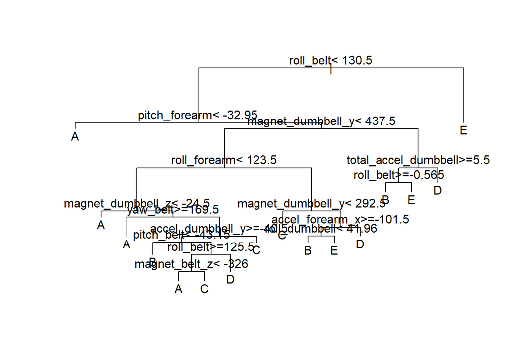

```r
#predTest <- predict(model, newdata=testing)



#summary(model)
par(xpd = NA)
plot(model$finalModel)
text(model$finalModel, digits = 3)
```

```r
predictTest = predict(model, newdata=testing,na.action=na.pass)
#predictTest
testing$classe = predictTest

varImp(model)
```

```
## rpart variable importance
##
##   only 20 most important variables shown (out of 52)
##
##                      Overall
## roll_belt             100.00
## pitch_forearm          79.56
## roll_forearm           66.46
## accel_dumbbell_y       60.14
## magnet_dumbbell_z      58.32
## yaw_belt               51.83
## pitch_belt             50.42
## magnet_dumbbell_y      43.72
## roll_dumbbell          42.01
## accel_belt_z           38.95
## yaw_arm                33.19
## total_accel_belt       31.29
## magnet_belt_y          29.77
## accel_forearm_x        29.69
## magnet_arm_x           27.42
## magnet_forearm_x       23.05
## magnet_belt_z          20.61
## accel_arm_x            20.18
## total_accel_dumbbell   14.25
## roll_arm               12.44
```

The 20 variables that are important based on percentage for this analysis is present in the output varImp(model)

# Validation

```r
print(predict(model, newdata=test))
```

```
##  [1] C A E D D C D D A A C E C A E D A A A B
## Levels: A B C D E
```